# Kestasioneran Data

```r
library(ggplot2)
library(tsibble)
library(tseries)
library(MASS)
library(rio)
```

```r
set.seed(8990)
```

## Stasioner dalam Rataan dan Ragam

Pada dasarnya, pembangkitan data ARIMA akan menghasilkan data yang stasioner dalam rataan dan ragam karena akan mengikuti fungsi *default*-nya yang mengikuti pembangkitan bilangan acak normal dengan `mean=0` dan `ragam=1` .

```r
stas1 <- import("https://raw.githubusercontent.com/akmalbasisjkusumah/MPDW/main/Data/Dataset%20Tugas%201.csv")
harga <- stas1[,-1]
periode <- seq(1:128)
stas1 <- cbind.data.frame(periode,harga)
stas <- ts(stas1$harga)
head(stas,10)
```

```
##  [1] 7797.63 7773.26 7576.27 7420.72 7545.40 7548.22 7823.68 7761.29 7746.17
## [10] 7846.05
```

### Plot *Time Series*

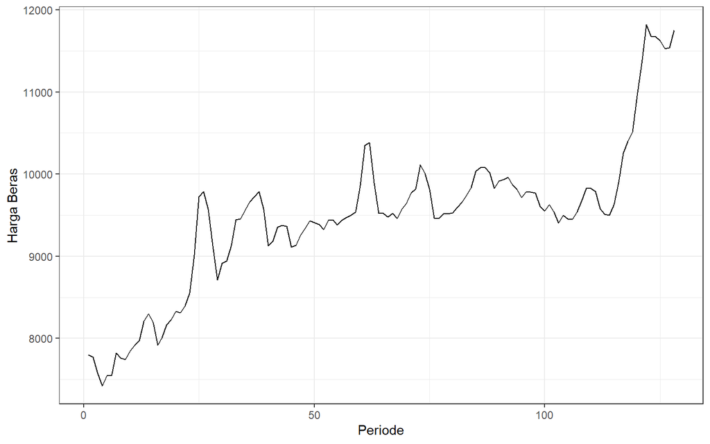

```r
plot_stas <- stas |> as_tsibble() |>
  ggplot(aes(x = periode, y = harga)) + geom_line() + theme_bw() +
  xlab("Periode") + ylab("Harga Beras")
plot_stas
```

```r
mean(stas)
```

```
## [1] 9454.057
```

Plot deret waktu di atas menunjukkan bahwa data tidak stasioner dalam rataan karena data tidak bergerak disekitar rataannya yaitu **9454.054**, dan juga data stasioner dalam ragam karena dapat dilihat lebar pitanya cenderung mirip

### Plot ACF

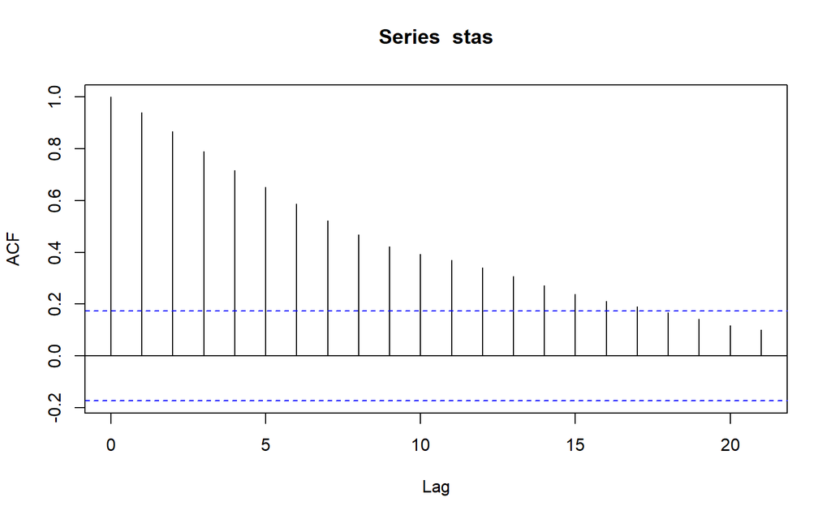

```r
acf(stas)
```

Berdasarkan plot ACF, terlihat bahwa plot ACF pada data tersebut cenderung *tails off slowly* artinya data tidak stasioner dalam rataan.

### Uji ADF

```r
tseries::adf.test(stas)
```

```
##
##  Augmented Dickey-Fuller Test
##
## data:  stas
## Dickey-Fuller = -2.1762, Lag order = 5, p-value = 0.5033
## alternative hypothesis: stationary
```

$H_0$ : Data tidak stasioner dalam rataan

$H_1$ : Data stasioner dalam rataan

Berdasarkan uji ADF tersebut, didapat *p-value* sebesar **0.5033** yang lebih besar dari taraf nyata 5% sehingga tak tolak $H_0$ dan menandakan bahwa data tidak stasioner dalam rataan. Hal ini sesuai dengan hasil eksplorasi menggunakan plot time series dan plot ACF.

### Plot Box-Cox

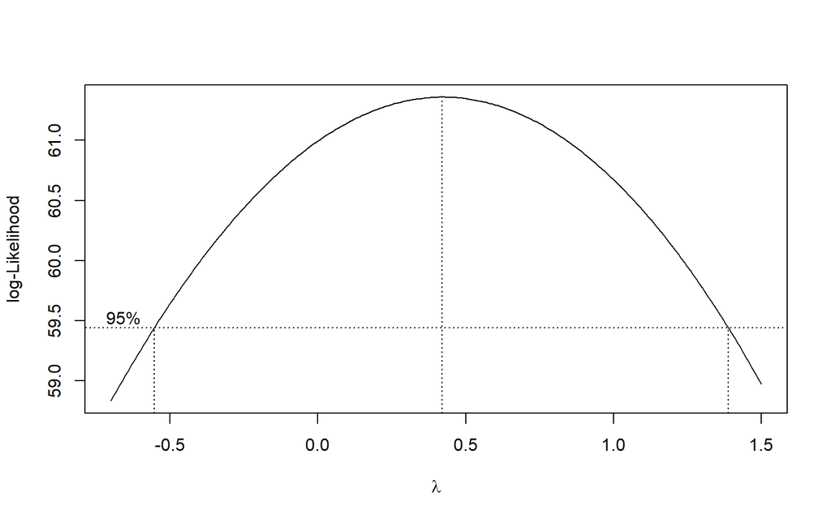

```r
index <- seq(1:128)
bc = boxcox(stas~index, lambda = seq(-0.7,1.5,by=0.01))
```

```r
#Nilai Rounded Lambda
lambda <- bc$x[which.max(bc$y)]
lambda
```

```
## [1] 0.42
```

```r
#SK
bc$x[bc$y > max(bc$y) - 1/2 * qchisq(.95,1)]
```

```
##   [1] -5.500000e-01 -5.400000e-01 -5.300000e-01 -5.200000e-01 -5.100000e-01
##   [6] -5.000000e-01 -4.900000e-01 -4.800000e-01 -4.700000e-01 -4.600000e-01
##  [11] -4.500000e-01 -4.400000e-01 -4.300000e-01 -4.200000e-01 -4.100000e-01
##  [16] -4.000000e-01 -3.900000e-01 -3.800000e-01 -3.700000e-01 -3.600000e-01
##  [21] -3.500000e-01 -3.400000e-01 -3.300000e-01 -3.200000e-01 -3.100000e-01
##  [26] -3.000000e-01 -2.900000e-01 -2.800000e-01 -2.700000e-01 -2.600000e-01
##  [31] -2.500000e-01 -2.400000e-01 -2.300000e-01 -2.200000e-01 -2.100000e-01
##  [36] -2.000000e-01 -1.900000e-01 -1.800000e-01 -1.700000e-01 -1.600000e-01
##  [41] -1.500000e-01 -1.400000e-01 -1.300000e-01 -1.200000e-01 -1.100000e-01
##  [46] -1.000000e-01 -9.000000e-02 -8.000000e-02 -7.000000e-02 -6.000000e-02
##  [51] -5.000000e-02 -4.000000e-02 -3.000000e-02 -2.000000e-02 -1.000000e-02
##  [56]  1.110223e-16  1.000000e-02  2.000000e-02  3.000000e-02  4.000000e-02
##  [61]  5.000000e-02  6.000000e-02  7.000000e-02  8.000000e-02  9.000000e-02
##  [66]  1.000000e-01  1.100000e-01  1.200000e-01  1.300000e-01  1.400000e-01
##  [71]  1.500000e-01  1.600000e-01  1.700000e-01  1.800000e-01  1.900000e-01
```

[output cut: 24 more lines]

Gambar di atas menunjukkan nilai *rounded value* ($\lambda$) optimum sebesar **0.42** dan pada selang kepercayaan 95% nilai memiliki batas bawah **-0.55** dan batas atas **1.38**. Selang tersebut memuat nilai satu sehingga dapat dikatakan bahwa data stasioner dalam ragam.

### Partisi Data

#### Bagian 1

```r
dt_stas1 <- stas[1:50] |> ts()
mean(dt_stas1)
```

```
## [1] 8711.504
```

```r
var(dt_stas1)
```

```
## [1] 561081
```

#### Plot Time Series

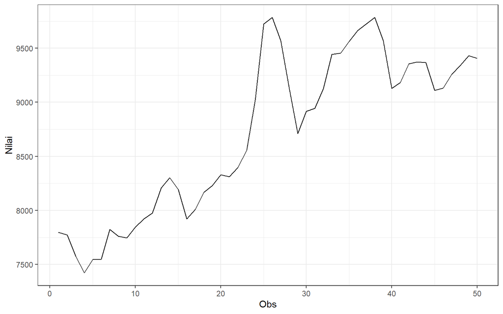

```r
dt_stas1 |> as_tsibble() |>
  ggplot(aes(x = index, y = value)) +
  geom_line() + theme_bw() +
  xlab("Obs") + ylab("Nilai")
```

Plot deret waktu di atas menunjukkan bahwa data tidak stasioner dalam rataan, ditandai dengan data yang tidak menyebar di sekitar nilai tengahnya **8711.504** dan stasioner dalam ragam, ditandai dengan lebar pita yang cenderung sama.

#### Plot ACF

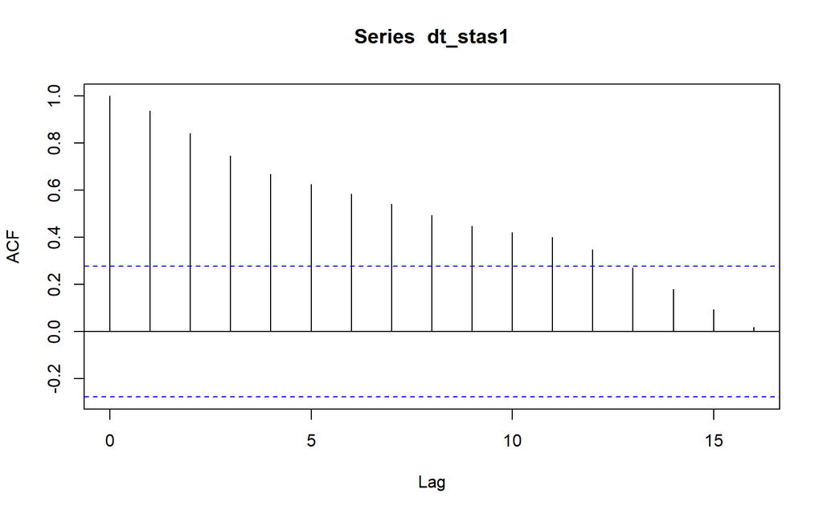

```r
acf(dt_stas1)
```

tails off perlahan = tidak stasioner, Berdasarkan plot ACF, terlihat bahwa plot ACF pada data tersebut cenderung *tails off slowly* yang menandakan bahwa data tidak stasioner terhadap rataannya.

#### Uji ADF

```r
tseries::adf.test(dt_stas1)
```

```
##
##  Augmented Dickey-Fuller Test
##
## data:  dt_stas1
## Dickey-Fuller = -1.869, Lag order = 3, p-value = 0.6268
## alternative hypothesis: stationary
```

$H_0$ : Data tidak stasioner dalam rataan

$H_1$ : Data stasioner dalam rataan

Berdasarkan uji ADF tersebut, didapat *p-value* sebesar **0.6268** yang lebih besar dari taraf nyata 5% sehingga tak tolak $H_0$ dan menandakan bahwa data tidak stasioner dalam rataan. Hal ini sesuai dengan hasil eksplorasi menggunakan plot time series dan plot ACF.

#### Plot Boxcox

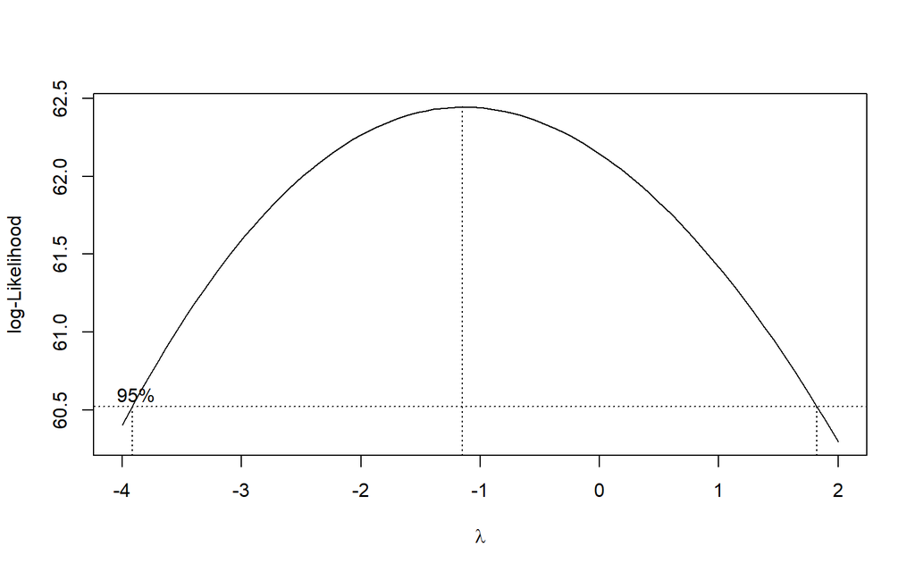

```r
index <- seq(1:50)
bc = boxcox(dt_stas1~index, lambda = seq(-4,2,by=1))
```

```r
#Nilai Rounded Lambda
lambda <- bc$x[which.max(bc$y)]
lambda
```

```
## [1] -1.151515
```

```r
#SK
bc$x[bc$y > max(bc$y) - 1/2 * qchisq(.95,1)]
```

```
##  [1] -3.87878788 -3.81818182 -3.75757576 -3.69696970 -3.63636364 -3.57575758
##  [7] -3.51515152 -3.45454545 -3.39393939 -3.33333333 -3.27272727 -3.21212121
## [13] -3.15151515 -3.09090909 -3.03030303 -2.96969697 -2.90909091 -2.84848485
## [19] -2.78787879 -2.72727273 -2.66666667 -2.60606061 -2.54545455 -2.48484848
## [25] -2.42424242 -2.36363636 -2.30303030 -2.24242424 -2.18181818 -2.12121212
## [31] -2.06060606 -2.00000000 -1.93939394 -1.87878788 -1.81818182 -1.75757576
## [37] -1.69696970 -1.63636364 -1.57575758 -1.51515152 -1.45454545 -1.39393939
## [43] -1.33333333 -1.27272727 -1.21212121 -1.15151515 -1.09090909 -1.03030303
## [49] -0.96969697 -0.90909091 -0.84848485 -0.78787879 -0.72727273 -0.66666667
## [55] -0.60606061 -0.54545455 -0.48484848 -0.42424242 -0.36363636 -0.30303030
## [61] -0.24242424 -0.18181818 -0.12121212 -0.06060606  0.00000000  0.06060606
## [67]  0.12121212  0.18181818  0.24242424  0.30303030  0.36363636  0.42424242
## [73]  0.48484848  0.54545455  0.60606061  0.66666667  0.72727273  0.78787879
## [79]  0.84848485  0.90909091  0.96969697  1.03030303  1.09090909  1.15151515
## [85]  1.21212121  1.27272727  1.33333333  1.39393939  1.45454545  1.51515152
## [91]  1.57575758  1.63636364  1.69696970  1.75757576  1.81818182
```

Gambar di atas menunjukkan nilai *rounded value* ($\lambda$) optimum sebesar **-1.1515** dan pada selang kepercayaan 95% nilai memiliki batas bawah **-3.8787** dan batas atas **1.8182**. Selang tersebut memuat nilai satu sehingga dapat dikatakan bahwa data stasioner dalam ragam.

#### Bagian 2

```r
dt_stas2 <- stas[1:100] |> ts()
mean(dt_stas2)
```

```
## [1] 9213.056
```

```r
var(dt_stas2)
```

```
## [1] 563521.4
```

#### Plot Time Series

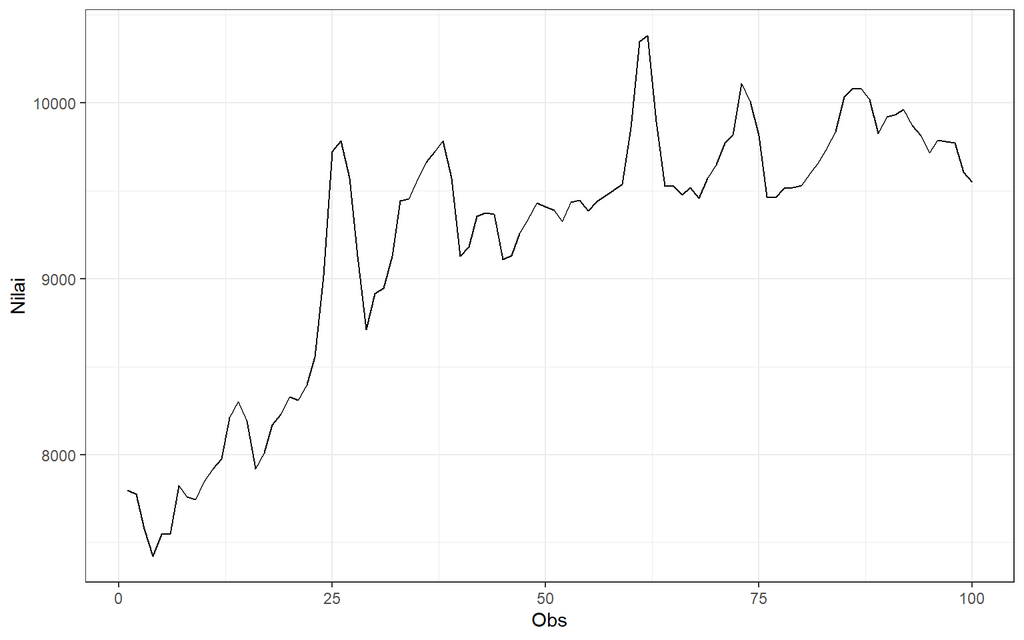

```r
dt_stas2 |> as_tsibble() |>
  ggplot(aes(x = index, y = value)) +
  geom_line() + theme_bw() +
  xlab("Obs") + ylab("Nilai")
```

Plot deret waktu di atas menunjukkan bahwa data tidak stasioner dalam rataan, ditandai dengan data yang tidak menyebar di sekitar nilai tengahnya **9213.056** dan tidak stasioner dalam ragam, ditandai dengan lebar pita yang cenderung tidak sama.

#### Plot ACF

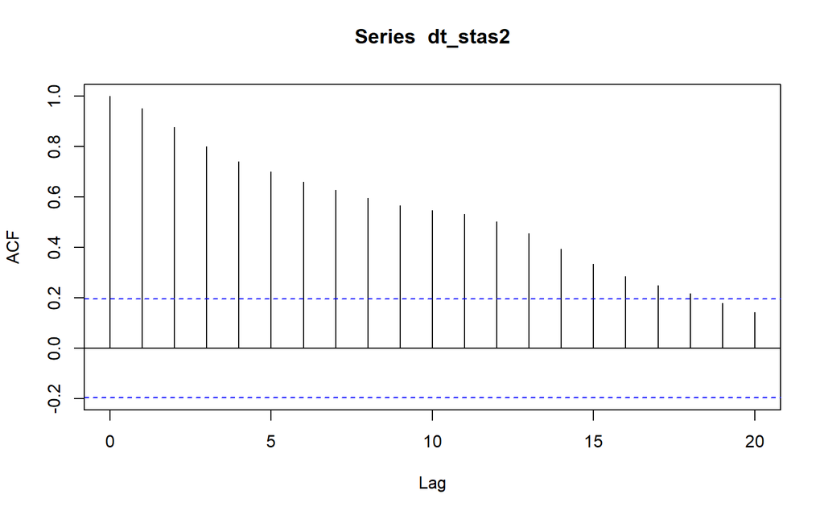

```r
acf(dt_stas2)
```

Berdasarkan plot ACF, terlihat bahwa plot ACF pada data tersebut cenderung *tails off slowly* yang menandakan bahwa data tidak stasioner dalam rataan.

#### Uji ADF

```r
adf.test(dt_stas2)
```

```
##
##  Augmented Dickey-Fuller Test
##
## data:  dt_stas2
## Dickey-Fuller = -1.9878, Lag order = 4, p-value = 0.5817
## alternative hypothesis: stationary
```

$H_0$ : Data tidak stasioner dalam rataan

$H_1$ : Data stasioner dalam rataan

Berdasarkan uji ADF tersebut, didapat *p-value* sebesar **0.5817** yang lebih besar dari taraf nyata 5% sehingga tak tolak $H_0$ dan menandakan bahwa data tidak stasioner dalam rataan. Hal ini sesuai dengan hasil eksplorasi menggunakan plot time series dan plot ACF.

#### Plot Boxcox

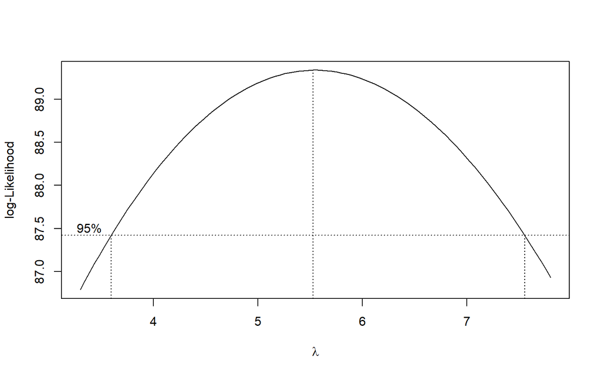

```r
index <- seq(1:100)
bc = boxcox(dt_stas2~index, lambda = seq(3.3,7.8,by=0.1))
```

```r
#Nilai Rounded Lambda
lambda <- bc$x[which.max(bc$y)]
lambda #untuk cek stasioner dalam ragam
```

```
## [1] 5.527273
```

```r
#SK
bc$x[bc$y > max(bc$y) - 1/2 * qchisq(.95,1)]
```

```
##  [1] 3.618182 3.663636 3.709091 3.754545 3.800000 3.845455 3.890909 3.936364
##  [9] 3.981818 4.027273 4.072727 4.118182 4.163636 4.209091 4.254545 4.300000
## [17] 4.345455 4.390909 4.436364 4.481818 4.527273 4.572727 4.618182 4.663636
## [25] 4.709091 4.754545 4.800000 4.845455 4.890909 4.936364 4.981818 5.027273
## [33] 5.072727 5.118182 5.163636 5.209091 5.254545 5.300000 5.345455 5.390909
## [41] 5.436364 5.481818 5.527273 5.572727 5.618182 5.663636 5.709091 5.754545
## [49] 5.800000 5.845455 5.890909 5.936364 5.981818 6.027273 6.072727 6.118182
## [57] 6.163636 6.209091 6.254545 6.300000 6.345455 6.390909 6.436364 6.481818
## [65] 6.527273 6.572727 6.618182 6.663636 6.709091 6.754545 6.800000 6.845455
## [73] 6.890909 6.936364 6.981818 7.027273 7.072727 7.118182 7.163636 7.209091
## [81] 7.254545 7.300000 7.345455 7.390909 7.436364 7.481818 7.527273
```